# re_ml_01

Elia Cornali

2025-06-01

## Setup

```r
# Import libraries

library(dplyr)
library(ggplot2)
library(readr)
library(tidyr)
library(caret)
library(recipes)
```

## Load data and functions

```r
# Load data
daily_fluxes <- readr::read_csv(
  here::here("./data/FLX_CH-Dav_FLUXNET2015_FULLSET_DD_1997-2014_1-3.csv"))


# Load functions
source(here::here("R/eval_model.R"))
source(here::here("R/eval_knn_diff_k.R"))
source(here::here("R/eval_knn_optimal_k.R"))
```

## Data wrangling

```r
daily_fluxes <- daily_fluxes |>

  # select only the variables we are interested in
  dplyr::select(TIMESTAMP,
                GPP_NT_VUT_REF,    # the target
                ends_with("_QC"),  # quality control info
                ends_with("_F"),   # includes all all meteorological covariates
                -contains("JSB")   # weird useless variable
                ) |>

  # convert to a nice date object
  dplyr::mutate(TIMESTAMP = lubridate::ymd(TIMESTAMP)) |>

  # set all -9999 to NA
  mutate(across(where(is.numeric), ~na_if(., -9999))) |>

  # retain only data based on >=80% good-quality measurements
  # overwrite bad data with NA (not dropping rows)
  dplyr::mutate(GPP_NT_VUT_REF = ifelse(NEE_VUT_REF_QC < 0.8, NA, GPP_NT_VUT_REF),
                TA_F           = ifelse(TA_F_QC        < 0.8, NA, TA_F),
                SW_IN_F        = ifelse(SW_IN_F_QC     < 0.8, NA, SW_IN_F),
                LW_IN_F        = ifelse(LW_IN_F_QC     < 0.8, NA, LW_IN_F),
                VPD_F          = ifelse(VPD_F_QC       < 0.8, NA, VPD_F),
                PA_F           = ifelse(PA_F_QC        < 0.8, NA, PA_F),
                P_F            = ifelse(P_F_QC         < 0.8, NA, P_F),
                WS_F           = ifelse(WS_F_QC        < 0.8, NA, WS_F)) |>

  # drop QC variables (no longer needed)
  dplyr::select(-ends_with("_QC"))
```

## Standardization

```r
# Standardization

daily_fluxes |>
  summarise(across(where(is.numeric),
                   ~quantile(.x, probs = c(0, 0.25, 0.5, 0.75, 1), na.rm = TRUE))) |>
  t() |>
  as_tibble(rownames = "variable") |>
  setNames(c("variable", "min", "q25", "q50", "q75", "max"))
```

```
## # A tibble: 8 × 6
##   variable           min     q25    q50    q75    max
##   <chr>            <dbl>   <dbl>  <dbl>  <dbl>  <dbl>
## 1 GPP_NT_VUT_REF  -4.23    0.773   2.87   5.45  12.3
## 2 TA_F           -21.9    -1.47    3.51   8.72  20.7
## 3 SW_IN_F          3.30   77.8   135.   214.   366.
## 4 LW_IN_F        138.    243.    279.   308.   365.
## 5 VPD_F            0.001   0.959   2.23   4.06  16.6
## 6 PA_F            80.4    83.2    83.7   84.1   85.6
## 7 P_F              0       0       0      1.6   92.1
## 8 WS_F             0.405   1.56    1.93   2.34   6.54
```

Adopt the code from this Chapter for fitting and evaluating the linear regression model and the KNN into your own RMarkdown file.Keep larger functions in a separate file in an appropriate directory and load the function definition as part of the RMarkdown.

## Fitting and evaluating the linear regression and the KNN models

## Data cleaning

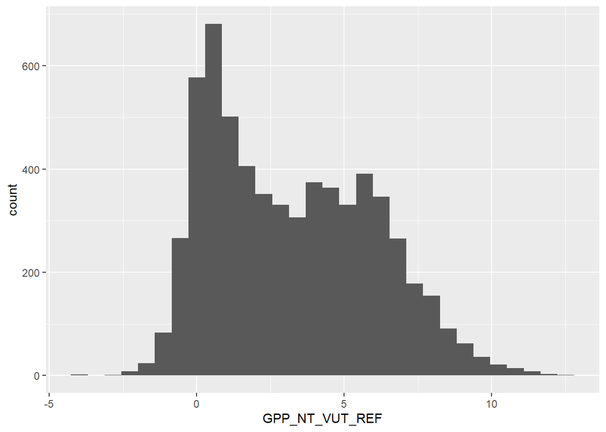

```r
# Data cleaning: looks ok, no obviously bad data
# no long tail, therefore no further target engineering

figure_0 <- ggplot(data = daily_fluxes, aes(x = GPP_NT_VUT_REF, y = ..count..)) +
  geom_histogram()

# Save figure in repository figures
ggplot2::ggsave(
  filename = here::here("figures", "Data cleaning.png"),
  plot = figure_0,
  width = 10, height = 6, dpi = 300
)
# Depict plot in html version
figure_0
```

## Data splitting and fitting

```r
# Data splitting
set.seed(1982)  # for reproducibility
split <- rsample::initial_split(daily_fluxes, prop = 0.7, strata = "VPD_F")
daily_fluxes_train <- rsample::training(split)
daily_fluxes_test <- rsample::testing(split)

# Model and pre-processing formulation, use all variables but LW_IN_F
pp <- recipes::recipe(GPP_NT_VUT_REF ~ SW_IN_F + VPD_F + TA_F,
                      data = daily_fluxes_train |> drop_na()) |>
  recipes::step_BoxCox(recipes::all_predictors()) |>
  recipes::step_center(recipes::all_numeric(), -recipes::all_outcomes()) |>
  recipes::step_scale(recipes::all_numeric(), -recipes::all_outcomes())

# Fit linear regression model
mod_lm <- caret::train(
  pp,
  data = daily_fluxes_train |> drop_na(),
  method = "lm",
  trControl = caret::trainControl(method = "none"),
  metric = "RMSE"
)
# Fit KNN model
mod_knn <- caret::train(
  pp,
  data = daily_fluxes_train |> drop_na(),
  method = "knn",
  trControl = caret::trainControl(method = "none"),
  tuneGrid = data.frame(k = 8),
  metric = "RMSE"
)
```

## Linear regression model evalutation

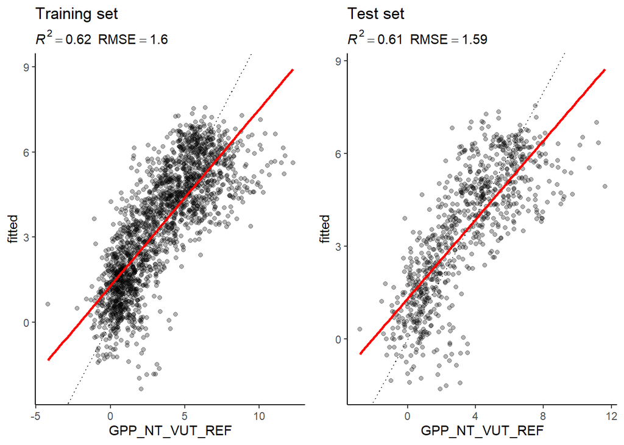

```r
# linear regression model
figure_1 <- eval_model(mod = mod_lm, df_train = daily_fluxes_train, df_test = daily_fluxes_test)

# Save figure in repository figures
ggplot2::ggsave(
  filename = here::here("figures", "Linear regression model evalutation.png"),
  plot = figure_1,
  width = 10, height = 6, dpi = 300
)

# Depict plot in html version
figure_1
```

## KNN model evalutation

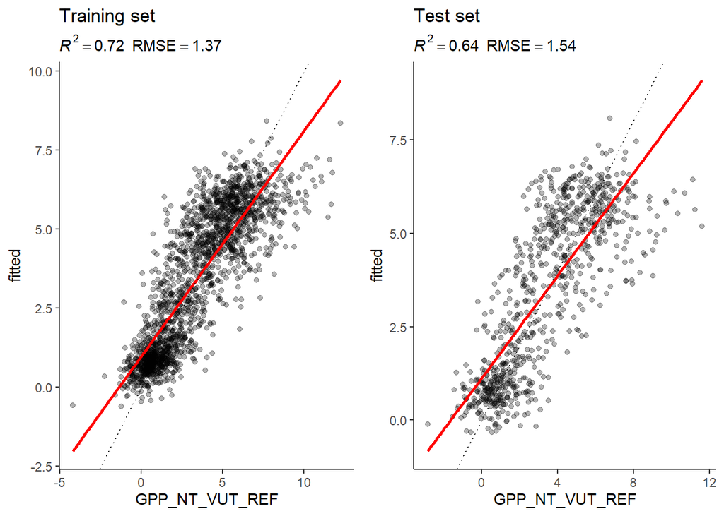

```r
# KNN model
figure_2 <- eval_model(mod = mod_knn, df_train = daily_fluxes_train, df_test = daily_fluxes_test)

# Save figure in repository figures
ggplot2::ggsave(
  filename = here::here("figures", "KNN model evalutation.png"),
  plot = figure_2,
  width = 10, height = 6, dpi = 300
)

# Depict plot in html version
figure_2
```

## Discussion

Why is the difference between the evaluation on the training and the test set larger for the KNN model than for the linear regression model?

The difference reflects the nature of KNN and linear regression related to bias-variance trade-off. KNN is a model with low-bias and high-variance, it therefore performs well on the training set (and overfitting it) but has more difficulties to generalize on the test set, resulting in a larger gap. Linear regression is a model with high-bias and low-variance. It may fit the training data less accurately but has stronger generalizability.

Why does the evaluation on the test set indicate a better model performance of the KNN model than the linear regression model?

This suggests that the relationship between data points is non-linear. Therefore KNN, that can investigate non-linear patterns, has better performance.

How would you position the KNN and the linear regression model along the spectrum of the bias-variance trade-off?

Linear regression is a high-bias and low-variance model, tends to underfitt data. KNN is a low-bias and high-variance model, tends to overfitt data.

## Temporal variations of observed and modelled GPP

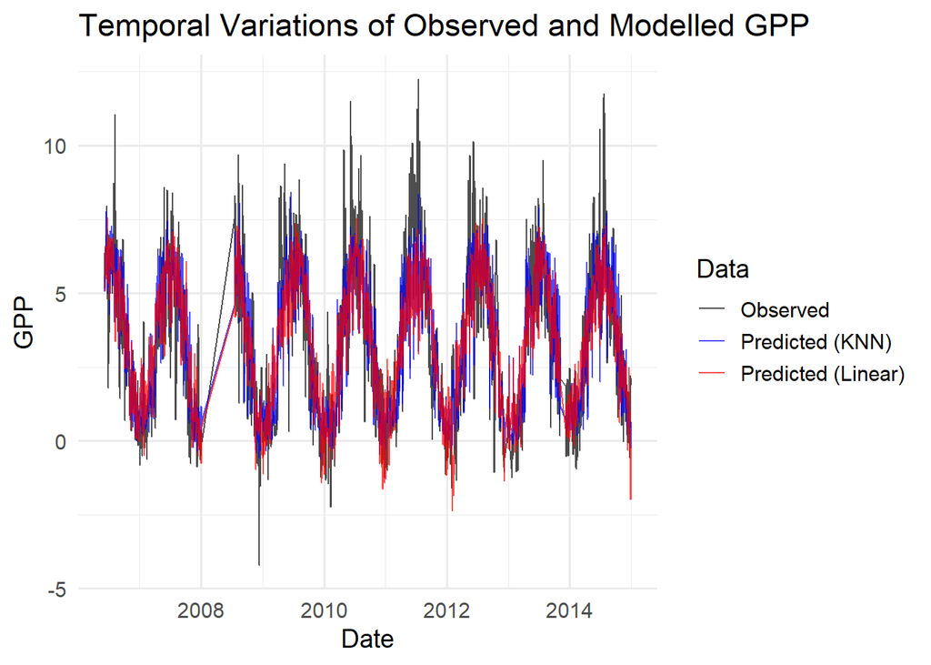

```r
# Drop NA
df <- daily_fluxes |> drop_na()

# Add predictions
df <- df |>
  mutate(
    pred_lm  = predict(mod_lm, newdata = df),
    pred_knn = predict(mod_knn, newdata = df)
  )

# Pivot longer for plotting
df_long <- df |>
  select(TIMESTAMP, GPP_NT_VUT_REF, pred_lm, pred_knn) |>
  pivot_longer(cols = c(GPP_NT_VUT_REF, pred_lm, pred_knn),
               names_to = "Data", values_to = "GPP") |>
  mutate(Data = recode(Data,
                         GPP_NT_VUT_REF = "Observed",
                         pred_lm = "Predicted (Linear)",
                         pred_knn = "Predicted (KNN)"))

# Plot: temporal variation
figure_3 <- ggplot(data = df_long,
       aes(x = TIMESTAMP, y = GPP, color = Data)) +
  geom_line(alpha = 0.7) +
  labs(title = "Temporal Variations of Observed and Modelled GPP",
       x = "Date", y = "GPP", color = "Data") +
  theme_minimal(base_size = 14) +
  scale_color_manual(values = c("black", "blue", "red"))

# Save figure in repository figures
ggplot2::ggsave(
  filename = here::here("figures", "Temporal variations of observed and modelled GPP.png"),
  plot = figure_3,
  width = 10, height = 6, dpi = 300
)

# Depict plot in html version
figure_3
```

From the visualization above we can see that both models fit the observed data well, even though they both fail in adressing peak values of GPP.

## The role of k

Based on your understanding of KNN (and without running code), state a hypothesis for how the R2 and the MAE evaluated on the test and on the training set would change for k approaching 1 and for k approaching N (the number of observations in the data). Explain your hypothesis, referring to the bias-variance trade-off.

The two cases indicate the extremes (min and max) of k values. For k approaching 1 the model would achieve perfect fit on the training set (R2 close to 1 and MAE close to 0 ) resulting in an overfitt because errors in the data are given to much weight. Therefore, for the test set the fit would be lower (R2 lower then 1 and MAE higher than 0). In terms of bias-variance trade-off: low bias and high variance For k approaching N the training set would be underfitted with R2 close to 0 and high MAE. The test set would also have low model performance but might have improved values due to less overfitting than with k approaching 1. In terms of bias-variance trade-off: high bias and low variance.

## Model with different k

Write code that splits the data into a training and a test set and repeats model fitting and evaluation for different values for k. Write (some of your) code into a function that takes k as an input and and returns the MAE determined on the test set.

```r
# Data splitting occured already in chunk 6

# define k values
k_values <- seq(1, 100, by = 2)

# Run evaluation and save results to data frame
results_df <- eval_knn_diff_k(
  k_values = k_values,
  df_train = daily_fluxes_train,
  df_test = daily_fluxes_test,
  recipe = pp
)
# Create table to visualize results
knitr::kable(
  results_df,
  format = "html",
  caption = "Results KNN diff k",
  align = "c",
  digits = 3)
```

Results KNN diff k

| k | rmse_train | rmse_test | rsq_train | rsq_test |
| --- | --- | --- | --- | --- |
| 1 | 0.000 | 2.008 | 1.000 | 0.478 |
| 3 | 1.171 | 1.677 | 0.798 | 0.584 |
| 5 | 1.300 | 1.559 | 0.751 | 0.631 |
| 7 | 1.348 | 1.546 | 0.732 | 0.635 |
| 9 | 1.384 | 1.537 | 0.718 | 0.639 |
| 11 | 1.410 | 1.502 | 0.707 | 0.654 |
| 13 | 1.435 | 1.493 | 0.697 | 0.657 |
| 15 | 1.442 | 1.501 | 0.694 | 0.653 |
| 17 | 1.450 | 1.499 | 0.691 | 0.654 |
| 19 | 1.458 | 1.494 | 0.687 | 0.657 |
| 21 | 1.468 | 1.498 | 0.683 | 0.655 |
| 23 | 1.468 | 1.501 | 0.683 | 0.654 |
| 25 | 1.469 | 1.495 | 0.683 | 0.656 |
| 27 | 1.470 | 1.489 | 0.682 | 0.659 |
| 29 | 1.477 | 1.487 | 0.679 | 0.660 |
| 31 | 1.479 | 1.490 | 0.678 | 0.659 |
| 33 | 1.480 | 1.486 | 0.678 | 0.660 |
| 35 | 1.483 | 1.487 | 0.677 | 0.660 |
| 37 | 1.484 | 1.493 | 0.676 | 0.657 |
| 39 | 1.486 | 1.492 | 0.675 | 0.658 |
| 41 | 1.486 | 1.492 | 0.675 | 0.658 |
| 43 | 1.488 | 1.496 | 0.674 | 0.656 |
| 45 | 1.489 | 1.497 | 0.674 | 0.656 |
| 47 | 1.491 | 1.497 | 0.673 | 0.656 |
| 49 | 1.494 | 1.497 | 0.672 | 0.655 |
| 51 | 1.495 | 1.501 | 0.672 | 0.653 |
| 53 | 1.494 | 1.501 | 0.672 | 0.654 |
| 55 | 1.495 | 1.501 | 0.672 | 0.654 |
| 57 | 1.496 | 1.498 | 0.672 | 0.655 |
| 59 | 1.495 | 1.498 | 0.672 | 0.655 |
| 61 | 1.497 | 1.499 | 0.671 | 0.655 |
| 63 | 1.498 | 1.499 | 0.671 | 0.655 |
| 65 | 1.502 | 1.496 | 0.669 | 0.656 |
| 67 | 1.503 | 1.498 | 0.669 | 0.656 |
| 69 | 1.505 | 1.496 | 0.668 | 0.656 |
| 71 | 1.506 | 1.498 | 0.667 | 0.655 |
| 73 | 1.508 | 1.500 | 0.666 | 0.655 |
| 75 | 1.509 | 1.498 | 0.666 | 0.655 |
| 77 | 1.511 | 1.500 | 0.665 | 0.655 |
| 79 | 1.512 | 1.499 | 0.665 | 0.655 |
| 81 | 1.512 | 1.500 | 0.665 | 0.655 |
| 83 | 1.514 | 1.499 | 0.664 | 0.655 |
| 85 | 1.516 | 1.500 | 0.663 | 0.655 |
| 87 | 1.515 | 1.498 | 0.664 | 0.655 |
| 89 | 1.516 | 1.497 | 0.663 | 0.656 |
| 91 | 1.516 | 1.499 | 0.663 | 0.655 |
| 93 | 1.517 | 1.500 | 0.663 | 0.655 |
| 95 | 1.518 | 1.501 | 0.663 | 0.655 |
| 97 | 1.518 | 1.499 | 0.662 | 0.655 |
| 99 | 1.519 | 1.502 | 0.662 | 0.654 |

## Visualization of model generalisability & complexity

Visualize results, showing model generalisability as a function of model complexity. Describe how a “region” of overfitting and underfitting can be determined in your visualisation.

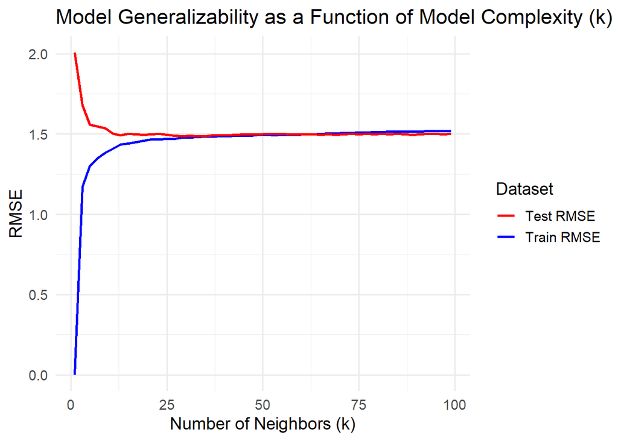

```r
# Visualise RMSE vs. k
figure_4 <- ggplot(data = results_df,
       aes(x = k)) +
  geom_line(aes(y = rmse_train, color = "Train RMSE"), size = 1) +
  geom_line(aes(y = rmse_test, color = "Test RMSE"), size = 1) +
  scale_color_manual(values = c("Train RMSE" = "blue", "Test RMSE" = "red")) +
  labs(title = "Model Generalizability as a Function of Model Complexity (k)",
       x = "Number of Neighbors (k)",
       y = "RMSE",
       color = "Dataset") +
  theme_minimal(base_size = 14)
# Save figure in repository figures
ggplot2::ggsave(
  filename = here::here("figures", "Visualization of model generalisability & complexity
.png"),
  plot = figure_4,
  width = 10, height = 6, dpi = 300
)
# Depict plot in html version
figure_4
```

The plot above shows the RMSE value compared to the k value for both the training and test sets. Lower k values are overfitting leading to a good model performance on the training set but a poor fit on the test set. High k values tent to underfit leading to a model that fails to represent the structure of the data.

Overfitting region This is the case at low k values and where the RMSE of the training set is very low and the RMSE of the test set much higher (big discrepancy between the two curves in the plot above)

## Optimal model

Is there an “optimal” in terms of model generalisability? Edit your code to determine an optimal

```r
# Run evaluation stopping at optimal k and save results to data frame
results_df_optimal <- eval_knn_optimal_k(
  k_values = k_values,
  df_train = daily_fluxes_train,
  df_test = daily_fluxes_test,
  recipe = pp
)
# Select row with smallest RMSE test
best_result <- results_df_optimal |>
  filter(rmse_test == min(rmse_test))

# Create table to visualize results
knitr::kable(
  best_result,
  format = "html",
  caption = "Results KNN optimal k",
  align = "c",
  digits = 4)
```

| k | rmse_train | rmse_test | rsq_train | rsq_test |
| --- | --- | --- | --- | --- |
| 13 | 1.4351 | 1.4927 | 0.6968 | 0.6572 |